# Penguin Assignment

## Reproducible Science in R and Figures - Assignment

- Question 01: What is the reproducibility crisis in science and should we care?
- Question 02: Create a figure using the Palmer Penguin dataset that is correct but badly communicates the data.
- Question 03: Discuss how colour choice is important for communication in science figures and what considerations should be made.
- Question 04: Run a statistical test on the Palmer Penguins dataset and produce a figure to explain it.
- Question 05: Download someone else’s example from Question 04.

## Question 04: Running a linear regression model between bill length and flipper length

### Loading the data

Make sure to set your working directory.

```r
# Check working directory has been set correctly
getwd()
```

```
## [1] "/Users/mel/Library/CloudStorage/OneDrive-Personal/Documents/_Year 3/Computing/MT 3 Data visualisation/Assignment"
```

Load the raw data and inspect column names:

```r
penguins_raw <- read.csv("data_raw/penguins_raw")
names(penguins_raw)
```

```
##  [1] "X"                   "studyName"           "Sample.Number"
##  [4] "Species"             "Region"              "Island"
##  [7] "Stage"               "Individual.ID"       "Clutch.Completion"
## [10] "Date.Egg"            "Culmen.Length..mm."  "Culmen.Depth..mm."
## [13] "Flipper.Length..mm." "Body.Mass..g."       "Sex"
## [16] "Delta.15.N..o.oo."   "Delta.13.C..o.oo."   "Comments"
```

### Cleaning the data

Clean the data:

```r
# Load the cleaning functions
source("functions/cleaning.r")

# Clean the data using the cleaning_columns function
penguins_clean <- cleaning_columns(penguins_raw)

# Inspect the clean data
names(penguins_clean)
```

```
##  [1] "study_name"        "sample_number"     "species"
##  [4] "region"            "island"            "stage"
##  [7] "individual_id"     "clutch_completion" "date_egg"
## [10] "culmen_length_mm"  "culmen_depth_mm"   "flipper_length_mm"
## [13] "body_mass_g"       "sex"
```

```r
# Preserve the clean data
write.csv(penguins_clean, "data_clean/penguins_clean")
```

### Running a linear regression model between flipper length and bill length

Subsetting the data to remove empty rows and only contain the data needed (flipper length and culmen length):

```r
#Filter the dataset
penguins_filtered <- remove_empty_data(penguins_clean)
#Inspect the filtered dataset
head(penguins_filtered)
```

```
##                               species flipper_length_mm culmen_length_mm
## 1 Adelie Penguin (Pygoscelis adeliae)               181             39.1
## 2 Adelie Penguin (Pygoscelis adeliae)               186             39.5
## 3 Adelie Penguin (Pygoscelis adeliae)               195             40.3
## 4 Adelie Penguin (Pygoscelis adeliae)               193             36.7
## 5 Adelie Penguin (Pygoscelis adeliae)               190             39.3
## 6 Adelie Penguin (Pygoscelis adeliae)               181             38.9
```

Check that flipper length and bill length are stored as continuous numerical variables:

```r
summary(penguins_filtered)
```

```
##    species          flipper_length_mm culmen_length_mm
##  Length:342         Min.   :172.0     Min.   :32.10
##  Class :character   1st Qu.:190.0     1st Qu.:39.23
##  Mode  :character   Median :197.0     Median :44.45
##                     Mean   :200.9     Mean   :43.92
##                     3rd Qu.:213.0     3rd Qu.:48.50
##                     Max.   :231.0     Max.   :59.60
```

**Testing the assumptions of Pearson’s correlation coefficient:**

- Expect a linear relationship between the two variables.
- Data from a random sample.
- Both variables follow normal distributions.

Can assume that the data was collected from a random sample.

What about a linear relationship between the 2 variables? First visualise the data using a quick scatterplot:

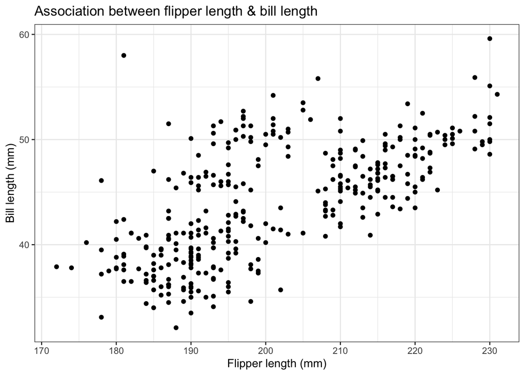

```r
# Load the plotting functions
source("functions/plotting_regression.r")

# Plot scatterplot between flipper length and culmen (bill) length
correlation_figure <- plot_correlation(penguins_filtered)
correlation_figure
```

From this plot, there appears to be a positive correlation between flipper length and bill length. So this meets the assumption of an expected linear relationship between the 2 variables.

Visual inspection of the data to check assumption of normality:

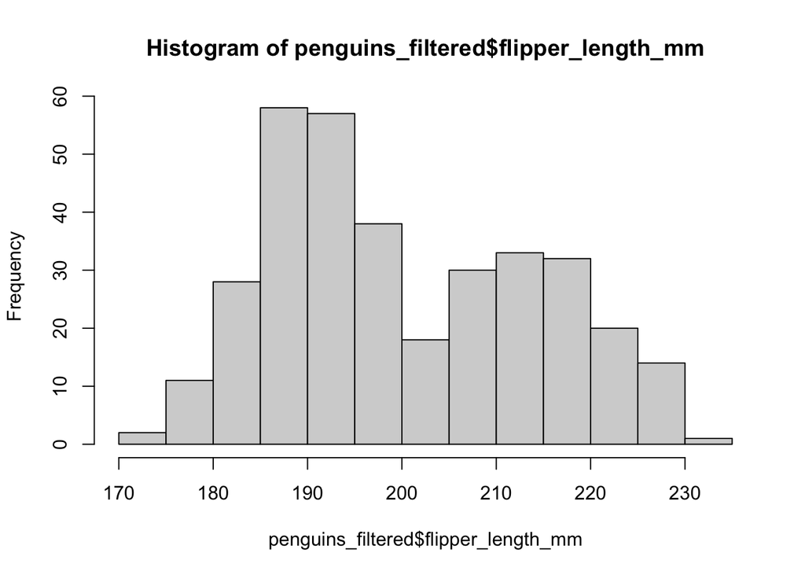

```r
 # Plot histograms:
hist(penguins_filtered$flipper_length_mm)
```

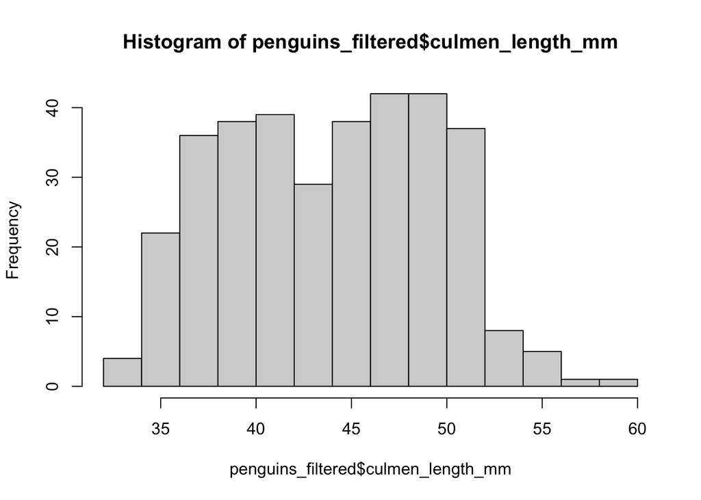

```r
hist(penguins_filtered$culmen_length_mm)
```

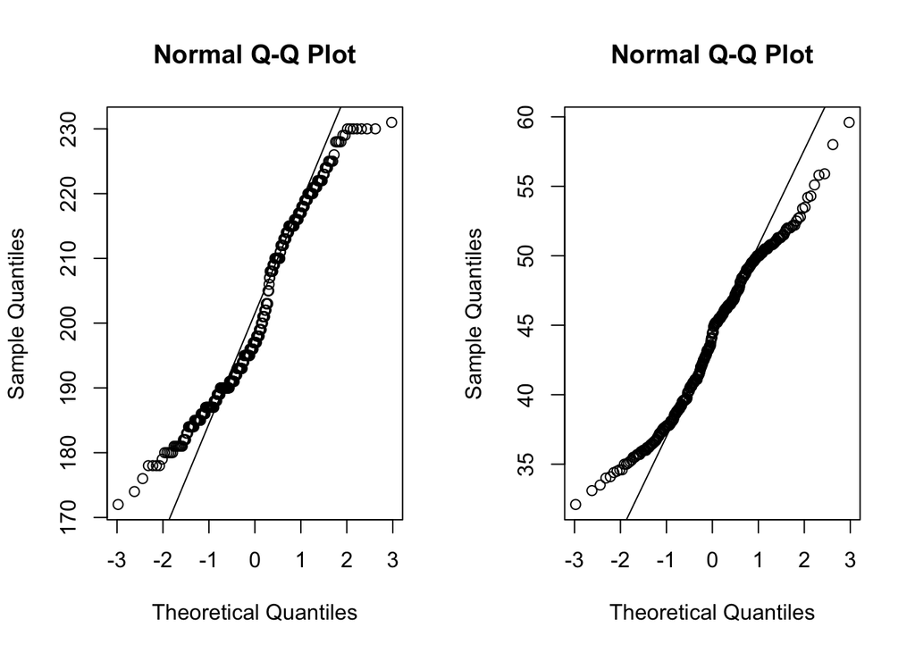

```r
# both are bimodal distributions

# Q-Q plots
par(mfrow=c(1,2))
qqnorm(penguins_filtered$flipper_length_mm)
qqline(penguins_filtered$flipper_length_mm)
qqnorm(penguins_filtered$culmen_length_mm)
qqline(penguins_filtered$culmen_length_mm)
```

The histograms are bimodal and the points on the QQ plots tend to stray from the diagonal line, so the assumption of normality may not be met. Can now apply a log transformation to the data to see if better meets assumption of normality.

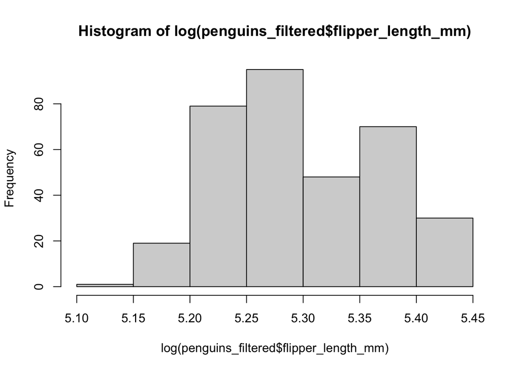

```r
 # Plot histograms:
hist(log(penguins_filtered$flipper_length_mm))
```

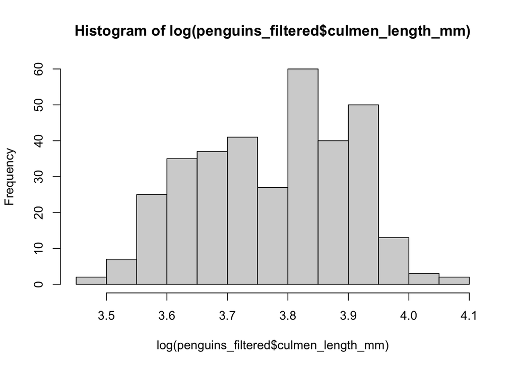

```r
hist(log(penguins_filtered$culmen_length_mm))
```

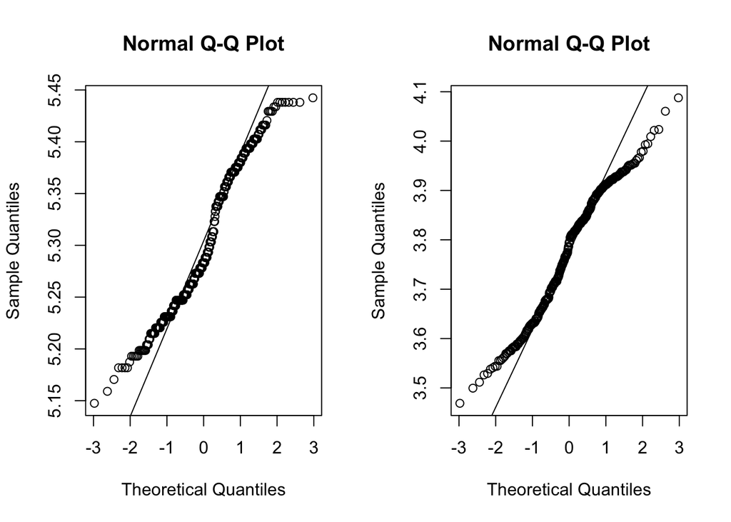

```r
# both are bimodal distributions

# Q-Q plots
par(mfrow=c(1,2))
qqnorm(log(penguins_filtered$flipper_length_mm))
qqline(log(penguins_filtered$flipper_length_mm))
qqnorm(log(penguins_filtered$culmen_length_mm))
qqline(log(penguins_filtered$culmen_length_mm))
```

QQ plots appear unchanged but the histograms seem to look slightly closer to a normal distribution.

**Pearson correlation test:**

```r
res <- cor.test(penguins_filtered$flipper_length_mm, penguins_filtered$culmen_length_mm,
                method = "pearson")
res
```

```
##
##  Pearson's product-moment correlation
##
## data:  penguins_filtered$flipper_length_mm and penguins_filtered$culmen_length_mm
## t = 16.034, df = 340, p-value < 2.2e-16
## alternative hypothesis: true correlation is not equal to 0
## 95 percent confidence interval:
##  0.5912769 0.7126403
## sample estimates:
##       cor
## 0.6561813
```

```r
# Extract the p-value
res$p.value
```

```
## [1] 1.743974e-43
```

```r
# Extract the correlation coefficient
res$estimate
```

```
##       cor
## 0.6561813
```

The p-value is <0.05 (and the 95% confidence interval does not overlap with zero) so there is sufficient evidence to reject the null hypothesis and conclude that there is a significant correlation between flipper length and bill length. The Pearson’s R value of 0.656 suggests that there is a significant positive correlation between flipper length and bill length.

#### (2) Using a linear regression model to test whether bill length can be used to predict flipper length.

**Checking that the data meets the assumptions of linear regression:**

- Independence of observations
- Normality
- Linearity
- Homoscedasticity (homogeneity of variance)

Fit the linear model:

```r
penguin_lm <- lm(flipper_length_mm ~ culmen_length_mm, data = penguins_filtered)

summary(penguin_lm)
```

```
##
## Call:
## lm(formula = flipper_length_mm ~ culmen_length_mm, data = penguins_filtered)
##
## Residuals:
##     Min      1Q  Median      3Q     Max
## -43.708  -7.896   0.664   8.650  21.179
##
## Coefficients:
##                  Estimate Std. Error t value Pr(>|t|)
## (Intercept)      126.6844     4.6651   27.16   <2e-16 ***
## culmen_length_mm   1.6901     0.1054   16.03   <2e-16 ***
## ---
## Signif. codes:  0 '***' 0.001 '**' 0.01 '*' 0.05 '.' 0.1 ' ' 1
##
## Residual standard error: 10.63 on 340 degrees of freedom
## Multiple R-squared:  0.4306, Adjusted R-squared:  0.4289
## F-statistic: 257.1 on 1 and 340 DF,  p-value: < 2.2e-16
```

Adjusted R^2 = 0.4289 and p-value < 0.05.

The results of this linear regression model suggest that there is a significant positive relationship between bill length and flipper length (p-value < 0.05), with a 1.69mm increase in flipper length for every mm increase in bill length. Using this model, bill length explains 43% of the variation in flipper length.

**Testing for homoscedasticity:**

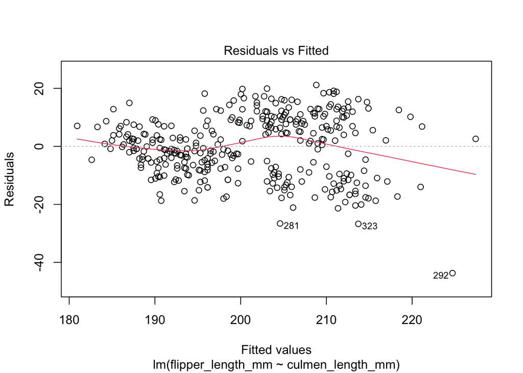

```r
#just residuals vs fitted plot -> tells you about assumption of equal variance
plot(penguin_lm, which = 1)
```

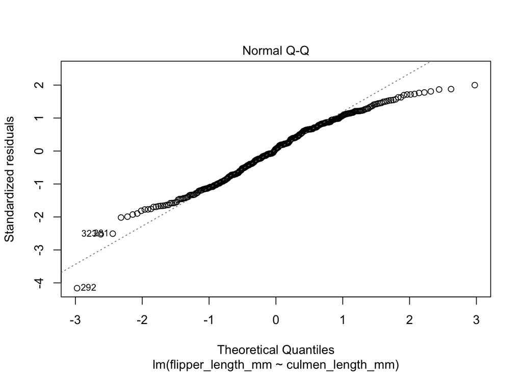

```r
#just normal Q-Q -> tells you about normality assumption
plot(penguin_lm, which = 2)
```

Residuals are the unexplained variance. The Residuals vs Fitted plot shows that the points are roughly evenly distributed above and below the zero line, however not perfectly. But the assumption appears to be fairly well met.

The Normal Q-Q plot shows that the points don’t seem to exactly follow the one-to-one line, and tail off at either end. This implies that the assumption of normality may not be met.

### Creating a figure to visualise the results

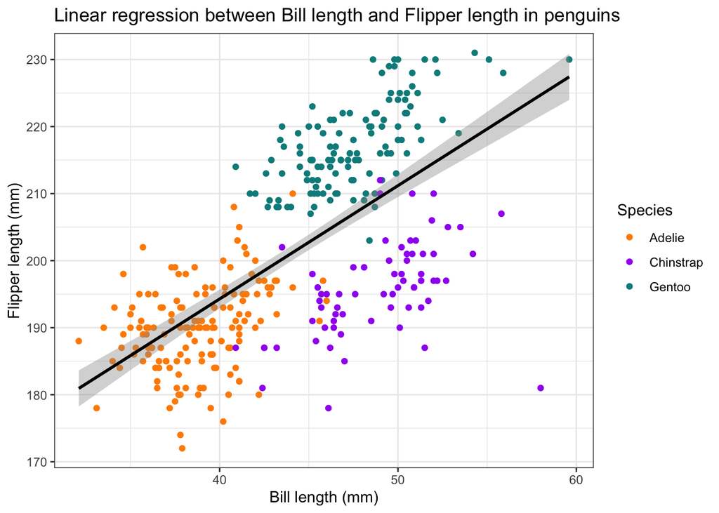

```r
#Plot a scatterplot with the linear regression model overlaid, using a function from plotting_regression.r
penguin_graph <- plot_penguin_lm(penguins_filtered)
penguin_graph
```

Overall, the results of this linear regression model suggest that there is a significant positive correlation between bill length and flipper length (p < 0.05, R^2 = 0.43), with a 1.69mm increase in flipper length for every mm increase in bill length.

### Finally, saving the figure

```r
#Save the figure using the a function from plotting_regression.r
save_plot_svg(penguins_filtered,
                      "figures/question04_vector.svg",
                      size = 15, scaling = 1)
```